# Definizione dei FTE e programmazione

## Metodologia

- Anno 2019
- Dati di attività da Business-Object (Darwin) della sezione di BG e SO
- Ore lavorate : dati delle presenze in minuti/mese per matricola dal software SIGMA (non più attivo dal 01/09/2020) del **personale di comparto**
- Unità di aggregazione dati : Laboratorio/tempo
- Tempo standard : 36 h/settimanali x 46.4 settimane lavorative (escluse 4.6 settimane di ferie pari a 28gg come da contratto )
- Calcolo del full time equivalent (FTE) per unità di aggregazione

## FTE

Full Time Equivalent

Indicatore delle risorse effettivamente disponibili per l’esecuzione di attività o progetti.

- 1 FTE = **un individuo a tempo pieno con contratto di 36h/settimanali**
- Una persona che lavora 18h in una settimana corrisponde a 18/36 = 0.5 FTE
- Una persona che lavora 40 h settimana corrisponde a 40/36 = 1.11 FTE
- Due persone che lavorano 18h settimana corrispondono a 2*18/36 = 1 FTE

FTE per aggregato : \[ \text{FTE}_{u} = \frac{\sum \text{numero ore erogate}_{u}}{\text{numero di ore standard}_{u} } \]

## Dati di Attività 2019

| Reparto | laboratorio | Totale conferimenti | Totale esami |
| --- | --- | --- | --- |
| Sede Territoriale di Bergamo | Accettazione | 36737 |  |
| Sede Territoriale di Sondrio | Accettazione | 34529 |  |
| Sede Territoriale di Bergamo | Laboratorio Sierologia |  | 148156 |
|  | Laboratorio Diagnostica Generale |  | 44639 |
|  | Laboratorio Microbiologia degli Alimenti |  | 9695 |
| Sede Territoriale di Sondrio | Laboratorio Sierologia |  | 86210 |
|  | Laboratorio Diagnostica Generale |  | 12552 |
|  | Laboratorio Microbiologia degli Alimenti |  | 9439 |

- 78 finalità
- 436 prove
- 121 tecniche

## Ripartizione del personale nei laboratori

| reparto | Matricola | hsett | htot | Laboratorio Sierologia | Laboratorio Microbiologia degli Alimenti | Laboratorio Diagnostica Generale | Amministrazione | Accettazione |
| --- | --- | --- | --- | --- | --- | --- | --- | --- |
| Sede Territoriale di Bergamo | 866 | 25 | 1160.0 | 95 | 0 | 5 | 0 | 0 |
|  | 1523 | 36 | 1670.4 | 0 | 100 | 0 | 0 | 0 |
|  | 634 | 36 | 1670.4 | 0 | 0 | 0 | 0 | 100 |
|  | 1046 | 36 | 1670.4 | 0 | 0 | 100 | 0 | 0 |
|  | 668 | 36 | 1670.4 | 90 | 0 | 10 | 0 | 0 |
|  | 1797 | 36 | 1670.4 | 0 | 100 | 0 | 0 | 0 |
|  | 1878 | 36 | 1670.4 | 0 | 0 | 0 | 0 | 100 |
|  | 1557 | 36 | 1670.4 | 0 | 0 | 100 | 0 | 0 |
|  | 1877 | 36 | 1670.4 | 0 | 0 | 0 | 90 | 10 |
| Sede Territoriale di Sondrio | 313 | 36 | 1670.4 | 25 | 50 | 25 | 0 | 0 |
|  | 629 | 36 | 1670.4 | 75 | 0 | 25 | 0 | 0 |
|  | 633 | 36 | 1670.4 | 0 | 5 | 20 | 0 | 75 |
|  | 735 | 36 | 1670.4 | 0 | 20 | 80 | 0 | 0 |
|  | 974 | 36 | 1670.4 | 15 | 80 | 5 | 0 | 0 |
|  | 927 | 36 | 1670.4 | 0 | 0 | 0 | 60 | 40 |

## Ripartizione del personale nei laboratori

Sede Territoriale di Bergamo

Matricola

hsett

htot

Laboratorio Sierologia

Laboratorio Microbiologia degli Alimenti

Laboratorio Diagnostica Generale

Amministrazione

Accettazione

866

25

1160.0

1102.00

0.0

58.00

0.00

0.00

1523

36

1670.4

0.00

1670.4

0.00

0.00

0.00

634

36

1670.4

0.00

0.0

0.00

0.00

1670.40

1046

36

1670.4

0.00

0.0

1670.40

0.00

0.00

668

36

1670.4

1503.36

0.0

167.04

0.00

0.00

1797

36

1670.4

0.00

1670.4

0.00

0.00

0.00

1878

36

1670.4

0.00

0.0

0.00

0.00

1670.40

1557

36

1670.4

0.00

0.0

1670.40

0.00

0.00

1877

36

1670.4

0.00

0.0

0.00

1503.36

167.04

Total

14523.2

2605.36

3340.8

3565.84

1503.36

3507.84

## Ripartizione del personale nei laboratori

Sede Territoriale di Sondrio

Matricola

hsett

htot

Laboratorio Sierologia

Laboratorio Microbiologia degli Alimenti

Laboratorio Diagnostica Generale

Amministrazione

Accettazione

313

36

1670.4

417.60

835.20

417.60

0.00

0.00

629

36

1670.4

1252.80

0.00

417.60

0.00

0.00

633

36

1670.4

0.00

83.52

334.08

0.00

1252.80

735

36

1670.4

0.00

334.08

1336.32

0.00

0.00

974

36

1670.4

250.56

1336.32

83.52

0.00

0.00

927

36

1670.4

0.00

0.00

0.00

1002.24

668.16

Total

10022.4

1920.96

2589.12

2589.12

1002.24

1920.96

## FTE per Reparto/laboratorio

| reparto | laboratorio | tempo-standard | tempo-lavorato | %tempo-stand utilizzato | FTE-disponibile | FTE-effettivo |
| --- | --- | --- | --- | --- | --- | --- |
| Sede Territoriale di Bergamo | Accettazione | 3508 | 2873 | 82 | 2.1 | 1.72 |
|  | Amministrazione | 1503 | 1207 | 80 | 0.9 | 0.72 |
|  | Laboratorio Diagnostica Generale | 3566 | 3471 | 97 | 2.1 | 2.08 |
|  | Laboratorio Microbiologia degli Alimenti | 3341 | 2792 | 84 | 2.0 | 1.67 |
|  | Laboratorio Sierologia | 2605 | 2385 | 92 | 1.6 | 1.43 |
| Sede Territoriale di Sondrio | Accettazione | 1921 | 1591 | 83 | 1.1 | 0.95 |
|  | Amministrazione | 1002 | 950 | 95 | 0.6 | 0.57 |
|  | Laboratorio Diagnostica Generale | 2589 | 2120 | 82 | 1.6 | 1.27 |
|  | Laboratorio Microbiologia degli Alimenti | 2589 | 2287 | 88 | 1.6 | 1.37 |
|  | Laboratorio Sierologia | 1921 | 1748 | 91 | 1.1 | 1.05 |

## Variazione mensile del FTE

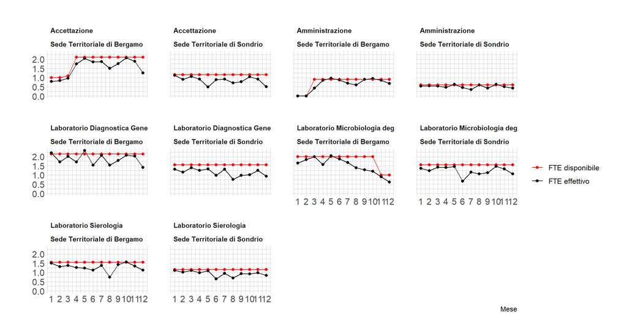

## Attività e FTE

| Reparto | laboratorio | tempo-standard | tempo-lavorato | %tempo-stand utilizzato | FTE-previsto | FTE-effettivo | Totale conferimenti | Totale esami |
| --- | --- | --- | --- | --- | --- | --- | --- | --- |
| Sede Territoriale di Bergamo | Accettazione | 3508 | 2873 | 82 | 2.1 | 1.72 | 36737 |  |
|  | Laboratorio Diagnostica Generale | 3566 | 3471 | 97 | 2.1 | 2.08 |  | 44639 |
|  | Laboratorio Microbiologia degli Alimenti | 3341 | 2792 | 84 | 2.0 | 1.67 |  | 9695 |
|  | Laboratorio Sierologia | 2605 | 2385 | 92 | 1.6 | 1.43 |  | 148156 |
| Sede Territoriale di Sondrio | Accettazione | 1921 | 1591 | 83 | 1.1 | 0.95 | 34529 |  |
|  | Laboratorio Diagnostica Generale | 2589 | 2120 | 82 | 1.6 | 1.27 |  | 12552 |
|  | Laboratorio Microbiologia degli Alimenti | 2589 | 2287 | 88 | 1.6 | 1.37 |  | 9439 |
|  | Laboratorio Sierologia | 1921 | 1748 | 91 | 1.1 | 1.05 |  | 86210 |

## esempio di programmazione basata sul FTE

| operatore | labA | labB | labC |
| --- | --- | --- | --- |
| A | 90 | 0 | 10 |
| B | 0 | 100 | 0 |
| C | 85 | 5 | 10 |
| D | 100 | 0 | 0 |
| E | 0 | 0 | 100 |
| F | 75 | 0 | 25 |
| G | 5 | 5 | 90 |
| H | 10 | 0 | 90 |

## esempio di programmazione basata sul FTE

| operatore | labA | labB | labC | Obiettivo A |
| --- | --- | --- | --- | --- |
| A | 90 | 0 | 10 | ? |
| B | 0 | 100 | 0 | ? |
| C | 85 | 5 | 10 | ? |
| D | 100 | 0 | 0 | ? |
| E | 0 | 0 | 100 | ? |
| F | 75 | 0 | 25 | ? |
| G | 5 | 5 | 90 | ? |
| H | 10 | 0 | 90 | ? |

## esempio di programmazione basata sul FTE

- Obiettivo A
- si stabilisce che per il raggiungimento di A occorre 1 FTE
- 1 FTE = una persona 36h/sett
  - 2 persone 0.5 FTE
  - 4 persone 0.25 FTE
  - 8 persone 0.125 FTE
- si decide di assegnare l’obiettivo a 8 operatori
- ore per persona a settimana da dedicare all’obiettivo = 0.125*36 = 4.5 h /settimana / persona
- ogni operatore coinvolto dovrà usare 4.5*46.4 = 208.8 h
- % di ore standard per operatore da allocare all’obiettivo = 208.8/1670.4 = 12.5%

## esempio di programmazione basata sul FTE

| operatore | labA | labB | labC | Obiettivo A |
| --- | --- | --- | --- | --- |
| A | 90 | 0 | 10 | ? |
| B | 0 | 100 | 0 | ? |
| C | 85 | 5 | 10 | ? |
| D | 100 | 0 | 0 | ? |
| E | 0 | 0 | 100 | ? |
| F | 75 | 0 | 25 | ? |
| G | 5 | 5 | 90 | ? |
| H | 10 | 0 | 90 | ? |

## esempio di programmazione basata sul FTE

| operatore | labA | labB | labC | Obiettivo A |
| --- | --- | --- | --- | --- |
| A | 90 | 0 | 10 | 12.5 |
| B | 0 | 100 | 0 | 12.5 |
| C | 85 | 5 | 10 | 12.5 |
| D | 100 | 0 | 0 | 12.5 |
| E | 0 | 0 | 100 | 12.5 |
| F | 75 | 0 | 25 | 12.5 |
| G | 5 | 5 | 90 | 12.5 |
| H | 10 | 0 | 90 | 12.5 |

## esempio di programmazione basata sul FTE

| operatore | labA | labB | labC | Obiettivo A |
| --- | --- | --- | --- | --- |
| A | 80.0 | 0 | 7.5 | 12.5 |
| B | 0.0 | 88 | 0.0 | 12.5 |
| C | 75.0 | 5 | 7.5 | 12.5 |
| D | 87.5 | 0 | 0.0 | 12.5 |
| E | 0.0 | 0 | 87.5 | 12.5 |
| F | 62.5 | 0 | 25.0 | 12.5 |
| G | 5.0 | 5 | 77.5 | 12.5 |
| H | 7.5 | 0 | 80.0 | 12.5 |

## esempio di programmazione basata sul FTE

| Operatore | labA | labB | labC | Obiettivo.A |
| --- | --- | --- | --- | --- |
| A | 1336 | 0 | 125 | 209 |
| B | 0 | 1462 | 0 | 209 |
| C | 1253 | 84 | 125 | 209 |
| D | 1462 | 0 | 0 | 209 |
| E | 0 | 0 | 1462 | 209 |
| F | 1044 | 0 | 418 | 209 |
| G | 84 | 84 | 1295 | 209 |
| H | 125 | 0 | 1336 | 209 |

## …da fare

- matrice di ripartizione matricola/laboratorio per tutte le strutture (app dedicata?) <- programmazione risorse disponibili
- estendere il calcolo del FTE a tutte le strutture per l’anno 2019 (2020 ?)
- definire le attività per la dirigenza
- definire le attività della ricerca